# SANTANDER - Prevendo o Nível de Satisfação dos Clientes do Santander

### 06/06/2021

### **Projeto de conclusão de curso -> Data Science Academy - Big Data Real-Time Analytics com Python e Spark**

## 1. Descrição do Projeto

Para este projeto será utilizada a linguagem **Python** e o dataset disponível pela competição [Santander Customer Satisfaction](https://www.kaggle.com/c/santander-customer-satisfaction), através do [Kaggle](https://www.kaggle.com/).

A satisfação do cliente é uma medida fundamental de sucesso. Clientes insatisfeitos cancelam seus serviços e raramente expressam sua insatisfação antes de sair. Clientes satisfeitos, por outro lado, se tornam defensores da marca!

O **Banco Santander** necessita identificar clientes insatisfeitos no início do relacionamento. Isso permitirá que o Santander adote medidas preventivas para melhorar a felicidade de um cliente antes que seja tarde demais.

Nesse projeto trabalharemos com centenas de recursos anônimos para prever se um cliente está satisfeito ou insatisfeito com sua experiência bancária.

## 1.1 Objetivo

Ao projeto será necessário a criação de um modelo de machine learning que preveja o **nível de satisfação dos clientes do Santander** ou seja , se o cliente está satisfeito.

Será considerado um algoritmo válido caso tenha uma **Acurácia** de **70%**.

## 2. Coleta dos Dados

```python
# Importanto as bibliotecas básicas necessárias para o processo de Data Munging.

# Ignorando mensagens de avisos.
import warnings
warnings.filterwarnings("ignore")

import numpy as np

import pandas as pd

import matplotlib.pyplot as plt
%matplotlib inline

import csv
```

```python
# Carregando os dados de treino e teste
treino_bruto = pd.read_csv('train.csv')
new_data = pd.read_csv('test.csv')
```

### Dados de Treino

```python
# Visualizando as 5 primeiras linhas dos dados de treino.
treino_bruto.head()
```

|  | ID | var3 | var15 | imp_ent_var16_ult1 | imp_op_var39_comer_ult1 | imp_op_var39_comer_ult3 | imp_op_var40_comer_ult1 | imp_op_var40_comer_ult3 | imp_op_var40_efect_ult1 | imp_op_var40_efect_ult3 | ... | saldo_medio_var33_hace2 | saldo_medio_var33_hace3 | saldo_medio_var33_ult1 | saldo_medio_var33_ult3 | saldo_medio_var44_hace2 | saldo_medio_var44_hace3 | saldo_medio_var44_ult1 | saldo_medio_var44_ult3 | var38 | TARGET |
| --- | --- | --- | --- | --- | --- | --- | --- | --- | --- | --- | --- | --- | --- | --- | --- | --- | --- | --- | --- | --- | --- |
| 0 | 1 | 2 | 23 | 0.0 | 0.0 | 0.0 | 0.0 | 0.0 | 0.0 | 0.0 | ... | 0.0 | 0.0 | 0.0 | 0.0 | 0.0 | 0.0 | 0.0 | 0.0 | 39205.170000 | 0 |
| 1 | 3 | 2 | 34 | 0.0 | 0.0 | 0.0 | 0.0 | 0.0 | 0.0 | 0.0 | ... | 0.0 | 0.0 | 0.0 | 0.0 | 0.0 | 0.0 | 0.0 | 0.0 | 49278.030000 | 0 |
| 2 | 4 | 2 | 23 | 0.0 | 0.0 | 0.0 | 0.0 | 0.0 | 0.0 | 0.0 | ... | 0.0 | 0.0 | 0.0 | 0.0 | 0.0 | 0.0 | 0.0 | 0.0 | 67333.770000 | 0 |
| 3 | 8 | 2 | 37 | 0.0 | 195.0 | 195.0 | 0.0 | 0.0 | 0.0 | 0.0 | ... | 0.0 | 0.0 | 0.0 | 0.0 | 0.0 | 0.0 | 0.0 | 0.0 | 64007.970000 | 0 |
| 4 | 10 | 2 | 39 | 0.0 | 0.0 | 0.0 | 0.0 | 0.0 | 0.0 | 0.0 | ... | 0.0 | 0.0 | 0.0 | 0.0 | 0.0 | 0.0 | 0.0 | 0.0 | 117310.979016 | 0 |

5 rows × 371 columns

### Dados para Previsão

```python
new_data.head()
```

|  | ID | var3 | var15 | imp_ent_var16_ult1 | imp_op_var39_comer_ult1 | imp_op_var39_comer_ult3 | imp_op_var40_comer_ult1 | imp_op_var40_comer_ult3 | imp_op_var40_efect_ult1 | imp_op_var40_efect_ult3 | ... | saldo_medio_var29_ult3 | saldo_medio_var33_hace2 | saldo_medio_var33_hace3 | saldo_medio_var33_ult1 | saldo_medio_var33_ult3 | saldo_medio_var44_hace2 | saldo_medio_var44_hace3 | saldo_medio_var44_ult1 | saldo_medio_var44_ult3 | var38 |
| --- | --- | --- | --- | --- | --- | --- | --- | --- | --- | --- | --- | --- | --- | --- | --- | --- | --- | --- | --- | --- | --- |
| 0 | 2 | 2 | 32 | 0.0 | 0.0 | 0.0 | 0.0 | 0.0 | 0.0 | 0.0 | ... | 0.0 | 0.0 | 0.0 | 0.0 | 0.0 | 0.0 | 0.0 | 0.0 | 0.0 | 40532.10 |
| 1 | 5 | 2 | 35 | 0.0 | 0.0 | 0.0 | 0.0 | 0.0 | 0.0 | 0.0 | ... | 0.0 | 0.0 | 0.0 | 0.0 | 0.0 | 0.0 | 0.0 | 0.0 | 0.0 | 45486.72 |
| 2 | 6 | 2 | 23 | 0.0 | 0.0 | 0.0 | 0.0 | 0.0 | 0.0 | 0.0 | ... | 0.0 | 0.0 | 0.0 | 0.0 | 0.0 | 0.0 | 0.0 | 0.0 | 0.0 | 46993.95 |
| 3 | 7 | 2 | 24 | 0.0 | 0.0 | 0.0 | 0.0 | 0.0 | 0.0 | 0.0 | ... | 0.0 | 0.0 | 0.0 | 0.0 | 0.0 | 0.0 | 0.0 | 0.0 | 0.0 | 187898.61 |
| 4 | 9 | 2 | 23 | 0.0 | 0.0 | 0.0 | 0.0 | 0.0 | 0.0 | 0.0 | ... | 0.0 | 0.0 | 0.0 | 0.0 | 0.0 | 0.0 | 0.0 | 0.0 | 0.0 | 73649.73 |

5 rows × 370 columns

```python
# verificando os total linhas e colunas nos dados de treino e teste.
print('Dados de treino:', treino_bruto.shape)
print('Dados para previsão:', new_data.shape)
```

```
Dados de treino: (76020, 371)
Dados para previsão: (75818, 370)
```

Podemos verificar que os dados de **treino** possuem uma quantidade superior de linhas aos dados de **teste** e o conjunto de teste não possui apenas a variável **target**.

Conforme a documentação oficial desse conjunto de dados, as variáveis desse dataset são **variáveis anônimas**, ou seja, não foi disponibilizado pelo **Santander** o que significam cada uma das **370** variáveis disponíveis. Dessa forma, não será realizada a análise exploratória dos dados, passaremos direto à **seleção de variáveis** e **pré-processamento dos dados**.

## 3. Seleção de variáveis

Antes de prosseguirmos para seleção de variáveis, vamos realizar uma análise estatística rápida das variáveis.

```python
treino_bruto.describe()
```

|  | ID | var3 | var15 | imp_ent_var16_ult1 | imp_op_var39_comer_ult1 | imp_op_var39_comer_ult3 | imp_op_var40_comer_ult1 | imp_op_var40_comer_ult3 | imp_op_var40_efect_ult1 | imp_op_var40_efect_ult3 | ... | saldo_medio_var33_hace2 | saldo_medio_var33_hace3 | saldo_medio_var33_ult1 | saldo_medio_var33_ult3 | saldo_medio_var44_hace2 | saldo_medio_var44_hace3 | saldo_medio_var44_ult1 | saldo_medio_var44_ult3 | var38 | TARGET |
| --- | --- | --- | --- | --- | --- | --- | --- | --- | --- | --- | --- | --- | --- | --- | --- | --- | --- | --- | --- | --- | --- |
| count | 76020.000000 | 76020.000000 | 76020.000000 | 76020.000000 | 76020.000000 | 76020.000000 | 76020.000000 | 76020.000000 | 76020.000000 | 76020.000000 | ... | 76020.000000 | 76020.000000 | 76020.000000 | 76020.000000 | 76020.000000 | 76020.000000 | 76020.000000 | 76020.000000 | 7.602000e+04 | 76020.000000 |
| mean | 75964.050723 | -1523.199277 | 33.212865 | 86.208265 | 72.363067 | 119.529632 | 3.559130 | 6.472698 | 0.412946 | 0.567352 | ... | 7.935824 | 1.365146 | 12.215580 | 8.784074 | 31.505324 | 1.858575 | 76.026165 | 56.614351 | 1.172358e+05 | 0.039569 |
| std | 43781.947379 | 39033.462364 | 12.956486 | 1614.757313 | 339.315831 | 546.266294 | 93.155749 | 153.737066 | 30.604864 | 36.513513 | ... | 455.887218 | 113.959637 | 783.207399 | 538.439211 | 2013.125393 | 147.786584 | 4040.337842 | 2852.579397 | 1.826646e+05 | 0.194945 |
| min | 1.000000 | -999999.000000 | 5.000000 | 0.000000 | 0.000000 | 0.000000 | 0.000000 | 0.000000 | 0.000000 | 0.000000 | ... | 0.000000 | 0.000000 | 0.000000 | 0.000000 | 0.000000 | 0.000000 | 0.000000 | 0.000000 | 5.163750e+03 | 0.000000 |
| 25% | 38104.750000 | 2.000000 | 23.000000 | 0.000000 | 0.000000 | 0.000000 | 0.000000 | 0.000000 | 0.000000 | 0.000000 | ... | 0.000000 | 0.000000 | 0.000000 | 0.000000 | 0.000000 | 0.000000 | 0.000000 | 0.000000 | 6.787061e+04 | 0.000000 |
| 50% | 76043.000000 | 2.000000 | 28.000000 | 0.000000 | 0.000000 | 0.000000 | 0.000000 | 0.000000 | 0.000000 | 0.000000 | ... | 0.000000 | 0.000000 | 0.000000 | 0.000000 | 0.000000 | 0.000000 | 0.000000 | 0.000000 | 1.064092e+05 | 0.000000 |
| 75% | 113748.750000 | 2.000000 | 40.000000 | 0.000000 | 0.000000 | 0.000000 | 0.000000 | 0.000000 | 0.000000 | 0.000000 | ... | 0.000000 | 0.000000 | 0.000000 | 0.000000 | 0.000000 | 0.000000 | 0.000000 | 0.000000 | 1.187563e+05 | 0.000000 |
| max | 151838.000000 | 238.000000 | 105.000000 | 210000.000000 | 12888.030000 | 21024.810000 | 8237.820000 | 11073.570000 | 6600.000000 | 6600.000000 | ... | 50003.880000 | 20385.720000 | 138831.630000 | 91778.730000 | 438329.220000 | 24650.010000 | 681462.900000 | 397884.300000 | 2.203474e+07 | 1.000000 |

8 rows × 371 columns

Podemos notar que na coluna **var3 --> 75%** dos valores são 2 e temos um valor mínimo de -999999. Claramente isso é um outlier.

Para tratamente desse outlier substituiremos todos os valores de **-999999** por **2**.

```python
# Removendo os outliers da var3
treino_bruto['var3'].replace(-999999,2,inplace=True)

# Avaliando a alteração
treino_bruto.describe()
```

|  | ID | var3 | var15 | imp_ent_var16_ult1 | imp_op_var39_comer_ult1 | imp_op_var39_comer_ult3 | imp_op_var40_comer_ult1 | imp_op_var40_comer_ult3 | imp_op_var40_efect_ult1 | imp_op_var40_efect_ult3 | ... | saldo_medio_var33_hace2 | saldo_medio_var33_hace3 | saldo_medio_var33_ult1 | saldo_medio_var33_ult3 | saldo_medio_var44_hace2 | saldo_medio_var44_hace3 | saldo_medio_var44_ult1 | saldo_medio_var44_ult3 | var38 | TARGET |
| --- | --- | --- | --- | --- | --- | --- | --- | --- | --- | --- | --- | --- | --- | --- | --- | --- | --- | --- | --- | --- | --- |
| count | 76020.000000 | 76020.000000 | 76020.000000 | 76020.000000 | 76020.000000 | 76020.000000 | 76020.000000 | 76020.000000 | 76020.000000 | 76020.000000 | ... | 76020.000000 | 76020.000000 | 76020.000000 | 76020.000000 | 76020.000000 | 76020.000000 | 76020.000000 | 76020.000000 | 7.602000e+04 | 76020.000000 |
| mean | 75964.050723 | 2.716483 | 33.212865 | 86.208265 | 72.363067 | 119.529632 | 3.559130 | 6.472698 | 0.412946 | 0.567352 | ... | 7.935824 | 1.365146 | 12.215580 | 8.784074 | 31.505324 | 1.858575 | 76.026165 | 56.614351 | 1.172358e+05 | 0.039569 |
| std | 43781.947379 | 9.447971 | 12.956486 | 1614.757313 | 339.315831 | 546.266294 | 93.155749 | 153.737066 | 30.604864 | 36.513513 | ... | 455.887218 | 113.959637 | 783.207399 | 538.439211 | 2013.125393 | 147.786584 | 4040.337842 | 2852.579397 | 1.826646e+05 | 0.194945 |
| min | 1.000000 | 0.000000 | 5.000000 | 0.000000 | 0.000000 | 0.000000 | 0.000000 | 0.000000 | 0.000000 | 0.000000 | ... | 0.000000 | 0.000000 | 0.000000 | 0.000000 | 0.000000 | 0.000000 | 0.000000 | 0.000000 | 5.163750e+03 | 0.000000 |
| 25% | 38104.750000 | 2.000000 | 23.000000 | 0.000000 | 0.000000 | 0.000000 | 0.000000 | 0.000000 | 0.000000 | 0.000000 | ... | 0.000000 | 0.000000 | 0.000000 | 0.000000 | 0.000000 | 0.000000 | 0.000000 | 0.000000 | 6.787061e+04 | 0.000000 |
| 50% | 76043.000000 | 2.000000 | 28.000000 | 0.000000 | 0.000000 | 0.000000 | 0.000000 | 0.000000 | 0.000000 | 0.000000 | ... | 0.000000 | 0.000000 | 0.000000 | 0.000000 | 0.000000 | 0.000000 | 0.000000 | 0.000000 | 1.064092e+05 | 0.000000 |
| 75% | 113748.750000 | 2.000000 | 40.000000 | 0.000000 | 0.000000 | 0.000000 | 0.000000 | 0.000000 | 0.000000 | 0.000000 | ... | 0.000000 | 0.000000 | 0.000000 | 0.000000 | 0.000000 | 0.000000 | 0.000000 | 0.000000 | 1.187563e+05 | 0.000000 |
| max | 151838.000000 | 238.000000 | 105.000000 | 210000.000000 | 12888.030000 | 21024.810000 | 8237.820000 | 11073.570000 | 6600.000000 | 6600.000000 | ... | 50003.880000 | 20385.720000 | 138831.630000 | 91778.730000 | 438329.220000 | 24650.010000 | 681462.900000 | 397884.300000 | 2.203474e+07 | 1.000000 |

8 rows × 371 columns

Para seguirmos com a seleção de variáveis primeiramente separaremos os dados de **treino** em **70% -Treino e 30% - Teste** para diminuirmos o overfitting sobre os dados.

```python
# Removendo a variável "ID" dos dados de treino
treino_bruto = treino_bruto.drop('ID', axis=1)
treino_bruto.shape
```

```
(76020, 370)
```

```python
# Verificando se há valores duplicados nos dados de treino.
treino_bruto.duplicated().sum()
```

```
4841
```

```python
# Removendo os valores duplicados dos dados de treino.
treino_bruto = treino_bruto.drop_duplicates()
treino_bruto.shape
```

```
(71179, 370)
```

```python
# Verificando se há valores NA's ou nulos nos dados de treino.
print('Valores NA: ', treino_bruto.isna().sum().sum())
print('Valores NULL: ', treino_bruto.isnull().sum().sum())
```

```
Valores NA:  0
Valores NULL:  0
```

```python
# Verificando os tipos das variáveis carregadas pelo Python e suas quantidades.
treino_bruto.dtypes.value_counts()
```

```
int64      259
float64    111
dtype: int64
```

Conforme vimos nao temos mais valores **duplicados** e nem valores **nulos** nos dados de treino. Vamos prosseguir para **seleção de variáveis**.

Faremos agora a divisão dos dados em treino e teste conforme mencionado anteriormente.

```python
# Importanto a biblioteca para divisão dos dados.
from sklearn.model_selection import train_test_split

# Definindo um seed e o percentual aos dados de teste
seed = 10
teste_size = 0.3

# Seperando as variáveis independentes da variável target (dependente)
x_treino_bruto = treino_bruto.drop('TARGET', axis=1)
y_treino_bruto = treino_bruto['TARGET']

# Criando os conjuntos de dados de treino e de teste.
X_treino, X_teste, Y_treino, Y_teste = train_test_split(x_treino_bruto, y_treino_bruto, test_size = teste_size, random_state = seed)
```

```python
# Validando a separação
print('Treino: ', X_treino.shape)
print('Teste: ', X_teste.shape)
```

```
Treino:  (49825, 369)
Teste:  (21354, 369)
```

```python
# Salvando os dados num arquivo CSV.
X_treino.to_csv('X_treino.csv')
X_teste.to_csv('X_teste.csv')
Y_treino.to_csv('Y_treino.csv')
Y_teste.to_csv('Y_teste.csv')
```

### Eliminando variáveis constantes e altamente correlacionáveis

Para identificarmos quais as variáveis **constantes** utilizaremos o algoritmo **Variance Threshold**.

Esse algoritmo verificará entre nossas variáveis independentes quais as variáveis que possuem o mesmo valor em todas as observações de nosso conjunto de dados ou uma **baixa variância**.

### 3.2 Variance Threshold

### Variáveis Constantes

```python
# Importando o algoritmo do pacote Scikit-learn
from sklearn.feature_selection import VarianceThreshold
```

```python
# Criando uma instância e aplicando o algoritmo VarianceThreshold
var_thers = VarianceThreshold(threshold=(0)).fit(X_treino)
```

Vejamos quantas variáveis foram consideradas **Constantes** e **Não Constantes**:

```python
# Verificando as quantidades das variáveis não constantes.
X_treino.columns[var_thers.get_support()].size
```

```
335
```

```python
# Verificando as quantidades das variáveis constantes.
vars_constantes = [coluna for coluna in X_treino.columns if coluna not in X_treino.columns[var_thers.get_support()]]
len(vars_constantes)
```

```
34
```

```python
# Imprimindo as variáveis constantes
vars_constantes
```

```
['ind_var2_0',
 'ind_var2',
 'ind_var27_0',
 'ind_var28_0',
 'ind_var28',
 'ind_var27',
 'ind_var41',
 'ind_var46_0',
 'ind_var46',
 'num_var27_0',
 'num_var28_0',
 'num_var28',
 'num_var27',
 'num_var41',
 'num_var46_0',
 'num_var46',
 'saldo_var28',
 'saldo_var27',
 'saldo_var41',
 'saldo_var46',
 'imp_amort_var18_hace3',
 'imp_amort_var34_hace3',
 'imp_reemb_var13_hace3',
 'imp_reemb_var33_hace3',
 'imp_trasp_var17_out_hace3',
 'imp_trasp_var33_out_hace3',
 'num_var2_0_ult1',
 'num_var2_ult1',
 'num_reemb_var13_hace3',
 'num_reemb_var33_hace3',
 'num_trasp_var17_out_hace3',
 'num_trasp_var33_out_hace3',
 'saldo_var2_ult1',
 'saldo_medio_var13_medio_hace3']
```

Como as variáveis **constantes** não ajudam na **acurácia** do modelo as removeremos de nossos dados.

```python
# Removendo as variáveis constantes
X_treino = X_treino.drop(vars_constantes, axis=1)
X_treino.shape
```

```
(49825, 335)
```

### Variáveis quasi-constantes

Passaremos agora à remoção das variáveis **quasi-constantes**, ou seja, possuem uma variação, entretanto é bem baixa.

```python
# Criando uma instância e aplicando o algoritmo VarianceThreshold
var_thers = VarianceThreshold(threshold=(0.01)).fit(X_treino)
```

```python
# Verificando as quantidades das variáveis não quasi-constantes.
print('Variáveis não quasi-constantes: ', X_treino.columns[var_thers.get_support()].size)

# Verificando as quantidades das variáveis quasi_constantes.
quasi_constantes = [coluna for coluna in X_treino.columns if coluna not in X_treino.columns[var_thers.get_support()]]
print('Variáveis quasi-constantes: ', len(quasi_constantes))
```

```
Variáveis não quasi-constantes:  271
Variáveis quasi-constantes:  64
```

```python
# Removendo as variáveis quasi-constantes
X_treino = X_treino.drop(quasi_constantes, axis=1)
X_treino.shape
```

```
(49825, 271)
```

Com as variáveis constantes removidas de nossos dados, passaremos às variáveis que apresentam uma **alta correlação**, positiva ou negativa, entre si.

Vamos utilizar um a função de correção **corr** para determinarmos as correlações.

### 3.3 Correlação

```python
# Criando um objeto contendo as correlações.
correlacoes = X_treino.corr()
```

Com a as correlações realizadas, criaremos agora uma função para identificar quais as variariáveis que se relacionam entre si mais de uma vez.

```python
def correlation(threshold):
    global correlacoes
    # Criando uma variável do tipo set
    colunas_rela = set()
    for i in range(len(correlacoes.columns)):
        for j in range(i):
            if abs(correlacoes.iloc[i, j]) > threshold: # necessitamos dos valores absolutos
                colname = correlacoes.columns[i]  # salvando o nome da coluna
                colunas_rela.add(colname)
    return colunas_rela
```

Aplicaremos uma função para que a função localize todas as variáveis que possuem correlação a partir de um **threshold** de **0.7**.

```python
# Aplicando a função.
cols_alta_corr = correlation(0.7)
```

```python
# transformando numa lista e verificando o tamanho.
cols_alta_corr = list(cols_alta_corr)
len(cols_alta_corr)
```

```
180
```

```python
# Verificando as 5 primeiras linhas
cols_alta_corr[:5]
```

```
['saldo_medio_var13_largo_ult1',
 'imp_trasp_var33_in_ult1',
 'num_var30_0',
 'num_var45_hace2',
 'ind_var10cte_ult1']
```

Conforme vimos temos **180** variáveis que apresentam uma alta correlação entre si. Para evitarmos a duplicidade das correlações removeremos a primeira ocorrência de correlação entre as variáveis encontradas.

```python
# Salvando os nomes das variáveis num arquivo csv e removendo de nosso cojunto de dados.
with open('alta_correlacao.csv', 'w', newline='') as myfile:
     wr = csv.writer(myfile, quoting=csv.QUOTE_ALL)
     wr.writerow(cols_alta_corr)

# Removendo as variáveis dos dados de treino.
X_treino = X_treino.drop(cols_alta_corr, axis=1)

# Validando a remoção
X_treino.shape
```

```
(49825, 91)
```

Com a remoção das variáveis de alta correlação diminuímos nosso conjunto de dados para **91 variáveis**. Entretanto, ainda não acabamos a etapa de seleção de variáveis. Utilizaremos a técnica **Information Gain - Mutual Information** para analisarmos quais as variáveis que mais apresentam relação com nossa variável **target**.

### 3.4 Information Gain - Mutual Information

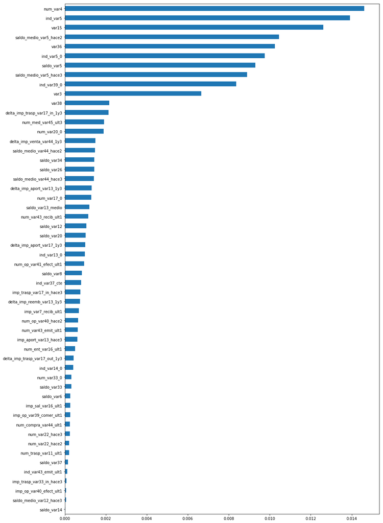

```python
# Carrengando o pacote necessário
from sklearn.feature_selection import mutual_info_classif

# Aplicando o Information Gain
mutual_info = mutual_info_classif(X_treino, Y_treino)

# Criando uma série com as informações encontradas.
mutual_info = pd.Series(mutual_info)

# Nomeando o indice.
mutual_info.index = X_treino.columns

# Ordenando e plotando o resultado.
mutual_info[mutual_info > 0].sort_values(ascending=True).plot(figsize=(15, 25), kind='barh')
```

```python
# Quantidades de variáveis independentes (= 0)
print('Variáveis independentes: ', len([x for x in mutual_info if x == 0]))

# Quantidade de variáveis dependentes
print('Variáveis dependentes: ', len([x for x in mutual_info if x > 0]))
```

```
Variáveis independentes:  37
Variáveis dependentes:  54
```

Aqui o que nos interessa são as variáveis **dependentes**, ou seja, que possuem alguma dependência com nossa variável **target**. Criaremos uma variável python para salvarmos as variáveis que apresentam relação.

```python
# Selecionando as variáveis que apresentam uma dependência.
dependencias_target = [x for x in mutual_info if x > 0]

# Verificando a quantidade de variáveis.
len(dependencias_target)
```

```
54
```

Entretanto para seleção das 54 variáveis com mais relacionamento. Utilizaremos um método ensemble para seleção das variáveis.

### 3.5 ExtraTreesClassifier

```python
# Importando o módulo necessário.
from sklearn.ensemble import ExtraTreesClassifier

# Criação do Modelo - Feature Selection
extraClassif = ExtraTreesClassifier().fit(X_treino, Y_treino)

# Criando um dataframe para visualização do resultado
best_variables = pd.DataFrame({'Variaveis': X_treino.columns,
                             'Importance': extraClassif.feature_importances_})

# imprimindo o resultado das 64 melhores variáveis
best_variables.sort_values('Importance', ascending=False)
```

|  | Variaveis | Importance |
| --- | --- | --- |
| 90 | var38 | 4.495132e-01 |
| 1 | var15 | 1.581119e-01 |
| 81 | saldo_medio_var5_hace3 | 6.088042e-02 |
| 80 | saldo_medio_var5_hace2 | 3.607810e-02 |
| 75 | num_med_var45_ult3 | 3.492811e-02 |
| 30 | saldo_var5 | 2.825677e-02 |
| 73 | num_var22_hace3 | 2.505617e-02 |
| 72 | num_var22_hace2 | 2.452301e-02 |
| 74 | num_var22_ult1 | 1.574759e-02 |
| 10 | ind_var5 | 1.508652e-02 |
| 43 | var36 | 1.303146e-02 |
| 3 | imp_op_var39_comer_ult1 | 1.260204e-02 |
| 23 | num_op_var41_hace2 | 1.218958e-02 |
| 6 | imp_op_var41_efect_ult1 | 1.086169e-02 |
| 18 | num_var4 | 1.073491e-02 |
| 76 | num_op_var41_efect_ult1 | 8.736345e-03 |
| 41 | saldo_var37 | 6.738622e-03 |
| 0 | var3 | 6.516854e-03 |
| 2 | imp_ent_var16_ult1 | 6.220668e-03 |
| 71 | num_ent_var16_ult1 | 5.261301e-03 |
| 78 | num_var43_recib_ult1 | 5.099592e-03 |
| 27 | num_var37_med_ult2 | 4.557114e-03 |
| 62 | imp_var43_emit_ult1 | 4.208793e-03 |
| 32 | saldo_var8 | 3.267016e-03 |
| 38 | saldo_var26 | 3.230764e-03 |
| 77 | num_var43_emit_ult1 | 3.211925e-03 |
| 24 | num_op_var41_hace3 | 2.899993e-03 |
| 11 | ind_var12_0 | 2.768862e-03 |
| 9 | ind_var5_0 | 2.713599e-03 |
| 16 | ind_var39_0 | 2.680357e-03 |
| ... | ... | ... |
| 28 | num_var44_0 | 7.049533e-05 |
| 70 | num_compra_var44_ult1 | 7.025027e-05 |
| 26 | num_var33_0 | 6.284899e-05 |
| 46 | delta_imp_reemb_var13_1y3 | 5.412854e-05 |
| 47 | delta_imp_reemb_var17_1y3 | 3.226822e-05 |
| 45 | delta_imp_aport_var17_1y3 | 2.373635e-05 |
| 88 | saldo_medio_var44_hace2 | 1.725427e-05 |
| 85 | saldo_medio_var13_largo_hace3 | 1.325571e-05 |
| 39 | saldo_var33 | 1.312383e-05 |
| 52 | delta_imp_venta_var44_1y3 | 1.095626e-05 |
| 68 | num_aport_var17_hace3 | 9.219386e-06 |
| 59 | imp_compra_var44_hace3 | 8.142951e-06 |
| 55 | imp_aport_var33_hace3 | 5.965566e-06 |
| 64 | imp_trasp_var17_in_ult1 | 5.241929e-06 |
| 37 | saldo_var20 | 5.076656e-06 |
| 89 | saldo_medio_var44_hace3 | 4.053212e-06 |
| 86 | saldo_medio_var29_hace2 | 3.391790e-06 |
| 48 | delta_imp_trasp_var17_in_1y3 | 3.145894e-06 |
| 31 | saldo_var6 | 3.098724e-06 |
| 34 | saldo_var13_medio | 2.955048e-06 |
| 50 | delta_imp_trasp_var33_in_1y3 | 2.916858e-06 |
| 49 | delta_imp_trasp_var17_out_1y3 | 6.812170e-07 |
| 65 | imp_trasp_var33_in_hace3 | 6.541058e-07 |
| 63 | imp_trasp_var17_in_hace3 | 5.288006e-07 |
| 56 | imp_aport_var33_ult1 | 1.052817e-07 |
| 87 | saldo_medio_var29_hace3 | 8.209296e-08 |
| 61 | imp_reemb_var17_hace3 | 2.368440e-08 |
| 51 | delta_imp_trasp_var33_out_1y3 | 2.222343e-08 |
| 57 | imp_var7_emit_ult1 | 1.115513e-08 |
| 40 | saldo_var34 | 9.624577e-10 |

91 rows × 2 columns

Podemos ver que existel algumas variáveis que apresentam uma baixíssima relação com nossa variável target. Faremos a remoção daquelas variáveis que apresentam uma relação **inferior** à **0.001**.

```python
# Removendo as variáveis indesejadas.
filtered_treino = X_treino[best_variables[best_variables['Importance'] > 0.001]['Variaveis'].array]

# Imprimindo o resultando.
filtered_treino.shape
```

```
(49825, 39)
```

```python
# Salvando o resultado num arquivo csv.
filtered_treino.to_csv('filtered_treino.csv')
```

## 4. Pré-processamento e Modelagem Preditiva

No pré-processamento precisamos realizar algumas transformações nas variáveis, pois muitos algoritmos de ML exigem que os dados esteja, **Padronizados**, **Normalizados**.

### Normalização

A normalização é quando colocamos os dados em uma escala com intervalo entre 0 e 1.

### Padronização

Padronização é a técnica para transformar os atributos com distribuição Gaussiana (normal) e diferentes médias e desvios padrão em uma distribuição Gaussiana com a média igual a 0 e desvio padrão igual a 1. Funciona bem quando os dados já estão na mesma escala (normalização).

Criaremos uma função para realizar a transformação nas variáveis e criação dos algoritmos. Utilizaremos a função **Pipeline** para criação do fluxo de transformação e criação do algoritmo.

Para realizarmos tais ações precisamos verificar se nossa variável target está balanceada ou não.

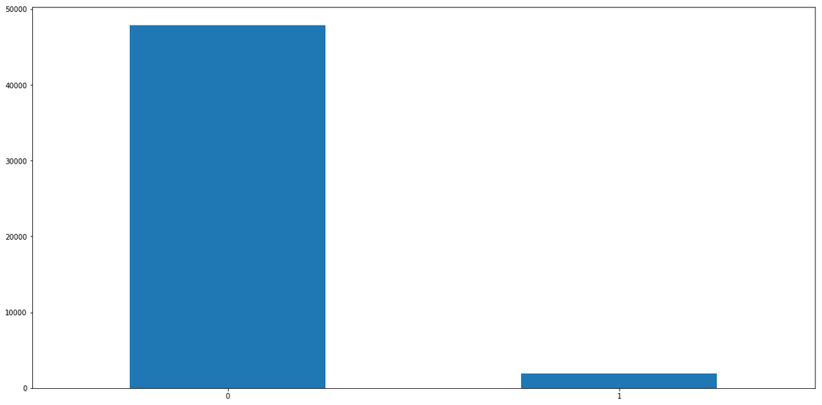

```python
# Verificando se os dados estão desbalanceados.
Y_treino.value_counts().plot(kind='bar', figsize=(20,10))
plt.xticks(rotation='0')
```

Conforme podemos ver acima, nossa variável target está totalmente desbalanceada. Temos muito mais valores **0** (cliente insatisfeito) do que **1** (cliente satisfeito).

Utilizaremos a função **SMOTE** para nos ajudar com o balanceamento da variável.

```python
# importando o pacote SMOTE.
from imblearn.over_sampling import SMOTE

# Criando uma instância do SMOTE.
SM = SMOTE(random_state=2)

# Aplicando balanceamento aos dados de treino.
x_train_smoted, y_train_smoted = SM.fit_resample(filtered_treino, Y_treino)
```

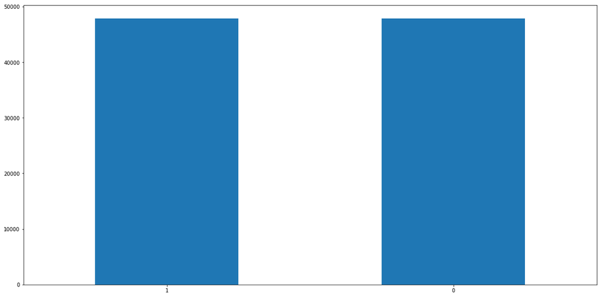

```python
y_train_smoted.value_counts().plot(kind='bar', figsize=(20,10))
plt.xticks(rotation=0)
```

Com os dados de treino balanceados podmos prosseguir com a etapa de modelagem preditiva, onde avaliaremos os melhores modelos para treinamento.

```python
# Pacote para criação de um fluxo de atividades.
from sklearn.pipeline import Pipeline

# Pacotes para transformação dos dados.
from sklearn.preprocessing import MinMaxScaler
from sklearn.preprocessing import Normalizer
from sklearn.preprocessing import Binarizer
from sklearn.preprocessing import StandardScaler

# Algoritmos de Machine Learning.
from sklearn.linear_model import LogisticRegression
from sklearn.discriminant_analysis import LinearDiscriminantAnalysis
from sklearn.neighbors import KNeighborsClassifier
from sklearn.naive_bayes import GaussianNB
from sklearn.tree import DecisionTreeClassifier
from sklearn.ensemble import RandomForestClassifier

# Pacotes para avaliação dos modelos criados.
from sklearn.model_selection import KFold
from sklearn.model_selection import cross_val_score

# Avaliação dos modelos
from sklearn.metrics import confusion_matrix
from sklearn.metrics import accuracy_score
from sklearn.metrics import roc_curve
from sklearn.metrics import auc
from sklearn.metrics import roc_auc_score
from sklearn.metrics import plot_roc_curve
```

Para avaliação dos algoritmos utilizaremos a **acurácia** dos modelos criados.

```python
# Criando função modelagem preditiva para avaliação dos algoritmos.
def modelagem_preditiva(x_treino, y_treino, kind=None):
    if kind=='Esc_Pad':

        # Criando uma lista com os transformadores.
        transformadores = [('MinMaxScaler',MinMaxScaler(feature_range = (0, 1))), ('Normalizer', Normalizer()),
                       ('Binarizer', Binarizer(threshold = 0.2))]

        # Criando uma lista com os algoritmos.
        algoritmos = [('LogisticRegression', LogisticRegression()), ('LinearDiscriminantAnalysis', LinearDiscriminantAnalysis()),
                     ('KNeighborsClassifier', KNeighborsClassifier()), ('GaussianNB', GaussianNB()),
                      ('DecisionTreeClassifier', DecisionTreeClassifier())]

        # Criando de  array criação dos indices.
        indice_1 = []
        indice_2 = []

        # Criando uma lista para armazenamento dos resultados.
        media = []
        desvio = []


        # Criando o fluxo de treinamento dos algoritmos.
        for nome1, transformador in transformadores:
            for nome2, algoritmo in algoritmos:

                # Preenchendo os arrays com os nomes para o indice.
                indice_1.append(nome1)
                indice_2.append(nome2)

                # Criando o pipeline para transformação e criação do modelo.
                piped = Pipeline([(nome1, transformador), ('StandardScaler', StandardScaler()), (nome2, algoritmo)])

                # Definindo o número de folds e um seed.
                folds = 10
                seed = 5

                # Criando o separador dos dados em folds.
                separador = KFold(folds, shuffle=True, random_state=seed)

                # Criando o modelo.
                Validation = cross_val_score(piped, x_treino, y_treino, cv=separador, scoring='accuracy')

                media.append(Validation.mean())
                desvio.append(Validation.std())

        # Criando e alimentando o indexador.
        indexador = []
        indexador.append(indice_1)
        indexador.append(indice_2)

        # Criando o indexador.
        index = pd.MultiIndex.from_arrays(indexador, names=('Transformadores', 'Algoritmos'))

        # criando um dataframe para computar as informações.
        resultados = pd.DataFrame({'Acuracia': media,
                                  'Desvio': desvio}, index=index)

    elif kind=='Pad':

        # Criando uma lista com os algoritmos.
        algoritmos = [('LogisticRegression', LogisticRegression()), ('LinearDiscriminantAnalysis', LinearDiscriminantAnalysis()),
                     ('KNeighborsClassifier', KNeighborsClassifier()), ('GaussianNB', GaussianNB()),
                      ('DecisionTreeClassifier', DecisionTreeClassifier())]

        # Criando de  array criação dos indices.
        indice_2 = []

        # Criando uma lista para armazenamento dos resultados.
        media = []
        desvio = []


        # Criando o fluxo de treinamento dos algoritmos.
        for nome2, algoritmo in algoritmos:

            # Preenchendo os arrays com os nomes para o indice.
            indice_2.append(nome2)

            # Criando o pipeline para transformação e criação do modelo.
            piped = Pipeline([('StandardScaler', StandardScaler()), (nome2, algoritmo)])

            # Definindo o número de folds e um seed.
            folds = 10
            seed = 5

            # Criando o separador dos dados em folds.
            separador = KFold(folds, shuffle=True, random_state=seed)

            # Criando o modelo.
            Validation = cross_val_score(piped, x_treino, y_treino, cv=separador, scoring='accuracy')

            media.append(Validation.mean())
            desvio.append(Validation.std())

        # Criando e alimentando o indexador.
        indexador = []
        indexador.append(indice_2)

        # criando um dataframe para computar as informações.
        resultados = pd.DataFrame({'Acuracia': media,
                                  'Desvio': desvio}, index=indexador)
    elif kind=='Esc':

        # Criando uma lista com os transformadores.
        transformadores = [('MinMaxScaler',MinMaxScaler(feature_range = (0, 1))), ('Normalizer', Normalizer()),
                       ('Binarizer', Binarizer(threshold = 0.2))]

        # Criando uma lista com os algoritmos.
        algoritmos = [('LogisticRegression', LogisticRegression()), ('LinearDiscriminantAnalysis', LinearDiscriminantAnalysis()),
                     ('KNeighborsClassifier', KNeighborsClassifier()), ('GaussianNB', GaussianNB()),
                      ('DecisionTreeClassifier', DecisionTreeClassifier())]

        # Criando de  array criação dos indices.
        indice_1 = []
        indice_2 = []

        # Criando uma lista para armazenamento dos resultados.
        media = []
        desvio = []


        # Criando o fluxo de treinamento dos algoritmos.
        for nome1, transformador in transformadores:
            for nome2, algoritmo in algoritmos:

                # Preenchendo os arrays com os nomes para o indice.
                indice_1.append(nome1)
                indice_2.append(nome2)

                # Criando o pipeline para transformação e criação do modelo.
                piped = Pipeline([(nome1, transformador), (nome2, algoritmo)])

                # Definindo o número de folds e um seed.
                folds = 10
                seed = 5

                # Criando o separador dos dados em folds.
                separador = KFold(folds, shuffle=True, random_state=seed)

                # Criando o modelo.
                Validation = cross_val_score(piped, x_treino, y_treino, cv=separador, scoring='accuracy')

                media.append(Validation.mean())
                desvio.append(Validation.std())

        # Criando e alimentando o indexador.
        indexador = []
        indexador.append(indice_1)
        indexador.append(indice_2)

        # Criando o indexador.
        index = pd.MultiIndex.from_arrays(indexador, names=('Transformadores', 'Algoritmos'))

        # criando um dataframe para computar as informações.
        resultados = pd.DataFrame({'Acuracia': media,
                                  'Desvio': desvio}, index=index)


    else:

        # Criando uma lista com os algoritmos.
        algoritmos = [('LogisticRegression', LogisticRegression()), ('LinearDiscriminantAnalysis', LinearDiscriminantAnalysis()),
                     ('KNeighborsClassifier', KNeighborsClassifier()), ('GaussianNB', GaussianNB()),
                      ('DecisionTreeClassifier', DecisionTreeClassifier())]

        # Criando de  array criação dos indices.
        indice_2 = []

        # Criando uma lista para armazenamento dos resultados.
        media = []
        desvio = []


        # Criando o fluxo de treinamento dos algoritmos.
        for nome2, algoritmo in algoritmos:

            # Preenchendo os arrays com os nomes para o indice.
            indice_2.append(nome2)

            # Criando o pipeline para transformação e criação do modelo.
            piped = Pipeline([(nome2, algoritmo)])

            # Definindo o número de folds e um seed.
            folds = 10
            seed = 5

            # Criando o separador dos dados em folds.
            separador = KFold(folds, shuffle=True, random_state=seed)

            # Criando o modelo.
            Validation = cross_val_score(piped, x_treino, y_treino, cv=separador, scoring='accuracy')

            media.append(Validation.mean())
            desvio.append(Validation.std())

        # Criando e alimentando o indexador.
        indexador = []
        indexador.append(indice_2)

        # criando um dataframe para computar as informações.
        resultados = pd.DataFrame({'Acuracia': media,
                                  'Desvio': desvio}, index=indexador)

    return resultados
```

### Algoritmos

```python
# Verificando apenas com os algoritmos.
resultados = modelagem_preditiva(x_train_smoted, y_train_smoted)

# Salvando os dados num arquivo csv.
resultados.sort_values('Acuracia', ascending=False).to_csv('modelos.csv')

# Visualizando os reusltados.
resultados.sort_values('Acuracia', ascending=False)
```

|  | Acuracia | Desvio |
| --- | --- | --- |
| DecisionTreeClassifier | 0.939456 | 0.002117 |
| KNeighborsClassifier | 0.853713 | 0.003305 |
| LinearDiscriminantAnalysis | 0.781949 | 0.003347 |
| LogisticRegression | 0.663849 | 0.024702 |
| GaussianNB | 0.531698 | 0.004532 |

### Algoritmos + Padronizador

```python
# Aplicando a função aos dados para treino apenas com padronizador.
resultados = modelagem_preditiva(x_train_smoted, y_train_smoted, 'Pad')

# Salvando os dados num arquivo csv.
resultados.sort_values('Acuracia', ascending=False).to_csv('melhore_modelos.csv')

# Visualizando os reusltados.
resultados.sort_values('Acuracia', ascending=False)
```

|  | Acuracia | Desvio |
| --- | --- | --- |
| DecisionTreeClassifier | 0.939237 | 0.002589 |
| KNeighborsClassifier | 0.904739 | 0.003405 |
| LogisticRegression | 0.805330 | 0.003259 |
| LinearDiscriminantAnalysis | 0.781949 | 0.003347 |
| GaussianNB | 0.597340 | 0.004352 |

### Algoritmos + Transformador

```python
# Aplicando a função aos dados para treino apenas com padronizador.
resultados = modelagem_preditiva(x_train_smoted, y_train_smoted, 'Esc')

# Salvando os dados num arquivo csv.
resultados.sort_values('Acuracia', ascending=False).to_csv('modelos_transformados.csv')

# Visualizando os reusltados.
resultados.sort_values('Acuracia', ascending=False)
```

| Transformadores | Algoritmos | Acuracia | Desvio |
| --- | --- | --- | --- |
| MinMaxScaler | DecisionTreeClassifier | 0.939624 | 0.001803 |
| Normalizer | DecisionTreeClassifier | 0.931652 | 0.002590 |
| MinMaxScaler | KNeighborsClassifier | 0.896527 | 0.002554 |
| Normalizer | KNeighborsClassifier | 0.873375 | 0.003525 |
| Binarizer | DecisionTreeClassifier | 0.832191 | 0.005230 |
|  | LogisticRegression | 0.824867 | 0.005056 |
|  | LinearDiscriminantAnalysis | 0.815966 | 0.004080 |
|  | KNeighborsClassifier | 0.811234 | 0.016114 |
| MinMaxScaler | LogisticRegression | 0.796607 | 0.003754 |
| Normalizer | LinearDiscriminantAnalysis | 0.785093 | 0.003602 |
| MinMaxScaler | LinearDiscriminantAnalysis | 0.781949 | 0.003347 |
| Binarizer | GaussianNB | 0.609825 | 0.004997 |
| MinMaxScaler | GaussianNB | 0.597340 | 0.004352 |
| Normalizer | LogisticRegression | 0.572078 | 0.005188 |
|  | GaussianNB | 0.554244 | 0.003435 |

### Algoritmos + Padronizador + Transformadores

```python
# Verificando com os transformadores.
resultados = modelagem_preditiva(x_train_smoted, y_train_smoted, 'Esc_Pad')

# Salvando os dados num arquivo csv.
resultados.sort_values('Acuracia', ascending=False).to_csv('melhore_modelos_transformados.csv')

# Visualizando os reusltados.
resultados.sort_values('Acuracia', ascending=False)
```

| Transformadores | Algoritmos | Acuracia | Desvio |
| --- | --- | --- | --- |
| MinMaxScaler | DecisionTreeClassifier | 0.939738 | 0.002645 |
| Normalizer | DecisionTreeClassifier | 0.934253 | 0.002710 |
|  | KNeighborsClassifier | 0.907341 | 0.003621 |
| MinMaxScaler | KNeighborsClassifier | 0.904708 | 0.003460 |
| Binarizer | DecisionTreeClassifier | 0.832181 | 0.005338 |
|  | LogisticRegression | 0.825129 | 0.005100 |
|  | KNeighborsClassifier | 0.819811 | 0.006936 |
|  | LinearDiscriminantAnalysis | 0.815966 | 0.004080 |
| Normalizer | LogisticRegression | 0.813929 | 0.003522 |
| MinMaxScaler | LogisticRegression | 0.805330 | 0.003259 |
| Normalizer | LinearDiscriminantAnalysis | 0.785093 | 0.003602 |
| MinMaxScaler | LinearDiscriminantAnalysis | 0.781949 | 0.003347 |
| Binarizer | GaussianNB | 0.610483 | 0.004815 |
| MinMaxScaler | GaussianNB | 0.597340 | 0.004352 |
| Normalizer | GaussianNB | 0.583142 | 0.003956 |

Podemos ver que o algoritmo **DecisionTree** com o transformador **MinMaxScaler** apresentou melhor resultado.

Selecionaremos o algoritmo **DecisionTreeClassifier**. Para avaliação dos modelos precisamos que os dados de teste estejam com as mesmas alterações realizadas nos dados de treino.

Iniciaremos filtrando as colunas que queremos nos dados.

```python
# Verificando total de colunas nos dados antes do filtro.
print('Total de colunas antes do filtro: ', X_teste.shape[1])

# Filtrando os dados.
filtered_teste = X_teste[filtered_treino.columns]

print('Total de colunas após o filtro: ', filtered_teste.shape[1])
```

```
Total de colunas antes do filtro:  369
Total de colunas após o filtro:  39
```

Com os dados filtrados podemos agora verificar se há desbalanceamento nos dados de teste.

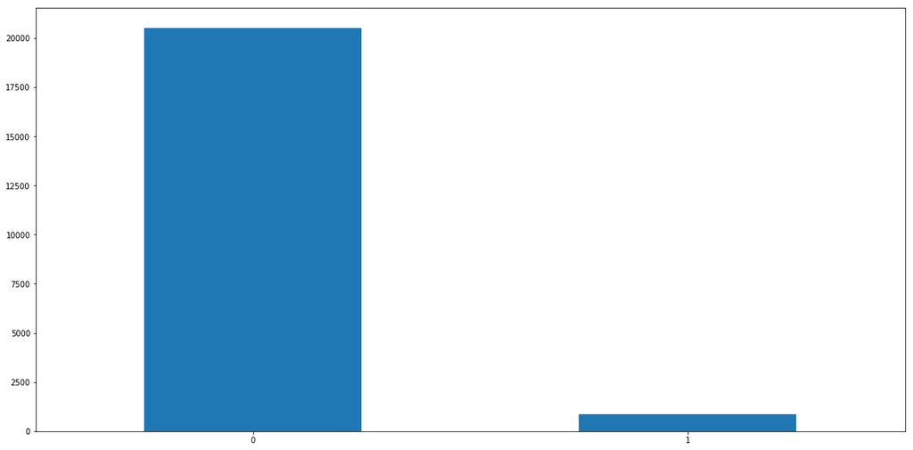

```python
# Verificando se há desbalanceamento entre as variáveis.
Y_teste.value_counts().plot('bar', figsize=(20,10))
plt.xticks(rotation='0')
```

Conforme podemos os dados de teste também estão desbalanceados. Utiliaremos o **SMOTE** para seguirmos com o balanceamento.

```python
# Aplicando balanceamento aos dados de teste.
x_teste_smoted, y_teste_smoted = SM.fit_resample(filtered_teste, Y_teste)
```

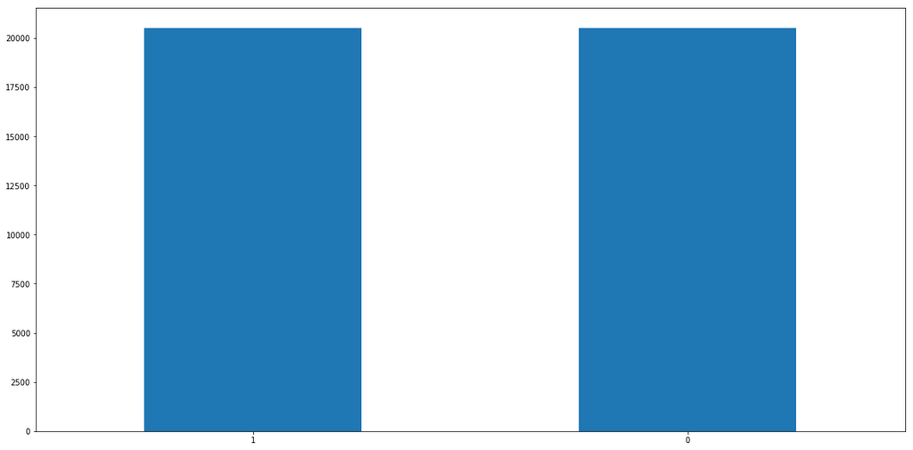

```python
# Verificando se os dados estão balanceados.
y_teste_smoted.value_counts().plot('bar', figsize=(20,10))
plt.xticks(rotation='0')
```

```python
# Criando uma função para treinamento dos modelos.
def treina_decision(treino_x, treino_y):

    # Pipeline com transformador e padronizador.
    pipe_escalado_padronizado = Pipeline([('MinMaxScaler',MinMaxScaler(feature_range = (0, 1))),('StandardScaler', StandardScaler()),
                          ('DecisionTreeClassifier', DecisionTreeClassifier())]).fit(treino_x, treino_y)

    pipe_padronizado = Pipeline([('StandardScaler', StandardScaler()),
                                 ('DecisionTreeClassifier', DecisionTreeClassifier())]).fit(treino_x, treino_y)

    pipe_escalado = Pipeline([('MinMaxScaler',MinMaxScaler(feature_range = (0, 1))),
                          ('DecisionTreeClassifier', DecisionTreeClassifier())]).fit(treino_x, treino_y)

    pipe_algoritmo = Pipeline([('DecisionTreeClassifier', DecisionTreeClassifier())]).fit(treino_x, treino_y)

    # Verificando os scores dos modelos.
    print('Score Escalado e Padronizado: ', round(pipe_escalado_padronizado.score(x_teste_smoted, y_teste_smoted), ndigits=3)*100)
    print('Score Padronizado: ', round(pipe_padronizado.score(x_teste_smoted, y_teste_smoted), ndigits=3)*100)
    print('Score Escalado: ', round(pipe_escalado.score(x_teste_smoted, y_teste_smoted), ndigits=3)*100)
    print('Score Apenas Modelos: ', round(pipe_algoritmo.score(x_teste_smoted, y_teste_smoted), ndigits=3)*100)
```

```python
# Aplicando a função.
treina_decision(x_train_smoted, y_train_smoted)
```

```
Score Escalado e Padronizado:  82.69999999999999
Score Padronizado:  82.6
Score Escalado:  82.39999999999999
Score Apenas Modelos:  82.8
```

Podemos perceber que o melhor resultado foi quando utilizamos apenas os modelos, sem nenhuma transformação nos dados. Utilizaremos o **DecisionTreeClassifier** para aplicarmos aos dados de teste e avaliarmos o modelo.

```
Accuracy:  82.89999999999999

Confusion Matrix:
 [[19013  1493]
 [ 5529 14977]]

AUC (Area Under Curve):  82.89999999999999

ROC CURVE:
```

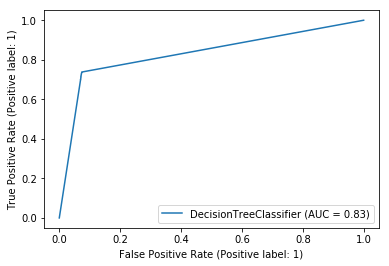

```python
# Criando o modelo.
decisionTree = DecisionTreeClassifier()

# Criando uma função para predição e avaliação do modelo criado.
def predict_avaliation(x_teste, y_teste, algoritmo):

    #treinando o modelo
    algoritmo.fit(x_train_smoted, y_train_smoted)

    # Realizando as predições.
    predicts = algoritmo.predict(x_teste)

    # Verificando a AUC do modelo
    fpr, tpr, thresholds = roc_curve(y_teste, predicts, pos_label=1)

    # Verificando estatítiscas do modelo.
    print('Accuracy: ', round(accuracy_score(y_teste, predicts), ndigits=3)*100)
    print('\nConfusion Matrix:\n', confusion_matrix(y_teste, predicts))
    print('\nAUC (Area Under Curve): ', round(auc(fpr, tpr), ndigits=3)*100)

    print('\nROC CURVE:')
    plot_roc_curve(algoritmo, x_teste, y_teste)
    plt.show()

    return algoritmo

# Aplicando a função
decicionTree = predict_avaliation(x_teste_smoted, y_teste_smoted, decisionTree)
```

Veremos se conseguimos melhorar a acurácia do algoritmo alterando alguns hiperparâmetros. Utilizaremos o método **Grid Search Parameter Tuning**, este método realiza metodicamente combinações entre todos os parâmetros do algoritmo, criando um grid.

## 5. Otimização

### 5.1 GridSearchCV

```python
# Importando o módulo necessário.
from sklearn.model_selection import GridSearchCV
```

```python
# Definindo os valores que serão testados.
valores_grid = {'min_samples_split': [5, 25, 50], 'min_samples_leaf': [2, 10, 50],
                'max_leaf_nodes': [2000, 5000, 8000]}

# Criando o selecionador
grid = GridSearchCV(decisionTree, valores_grid, cv=5, verbose=True, n_jobs=-1).fit(x_train_smoted, y_train_smoted)
```

```
Fitting 5 folds for each of 27 candidates, totalling 135 fits
```

```python
print('Acurácia: ', grid.best_score_ * 100)
grid.best_estimator_
```

```
Acurácia:  93.4400009373663
```

```
DecisionTreeClassifier(max_leaf_nodes=2000, min_samples_leaf=2,
                       min_samples_split=5)
```

Criaremos a versão dois de nosso modelo para averiguarmos se conseguimos melhorar a acurácia.

```python
# Criando e treinando um pipeline versão 2.
decisionTree_v2 = grid.best_estimator_

# Verificando o score do modelo.
print('Score: ', round(decisionTree_v2.score(x_train_smoted, y_train_smoted), ndigits=3)*100)
```

```
Score:  96.8
```

```
Accuracy:  84.89999999999999

Confusion Matrix:
 [[18804  1702]
 [ 4471 16035]]

AUC (Area Under Curve):  84.89999999999999

ROC CURVE:
```

[figure not shown]

```python
# Realizando as predições com a versão 2 do modelo.
decicionTree_V2 = predict_avaliation(x_teste_smoted, y_teste_smoted, decision_pipe_V2)
```

Tivemos uma melhora em nosso modelo. Vamos tentar melhorarmos o modelo ainda mais. Utilizaremos alguns **Métodos Ensemble** para vermos se conseguimos melhorar o resultado. Métodos Ensemble permitem aumentar consideravelmente o nível de precisão nas suas previsões.

### 5.3 RandomForestClassifier

Amostras do dataset de treino são usadas com reposição, mas as árvores são criadas de uma forma que reduz a correlação entre classificadores individuais (Random Forest é um conjunto de árvores de decisão).

Criaremos uma função ao random para avarialirmos a melhor forma de trabalharmos com ele.

```python
# Importando o algoritmo
from sklearn.ensemble import RandomForestClassifier

def treina_random(treino_x, treino_y):

    # Pipeline com transformador e padronizador.
    pipe_escalado_padronizado = Pipeline([('MinMaxScaler',MinMaxScaler(feature_range = (0, 1))),('StandardScaler', StandardScaler()),
                          ('RandomForestClassifier', RandomForestClassifier())]).fit(treino_x, treino_y)

    pipe_padronizado = Pipeline([('StandardScaler', StandardScaler()),
                                 ('RandomForestClassifier', RandomForestClassifier())]).fit(treino_x, treino_y)

    pipe_escalado = Pipeline([('MinMaxScaler',MinMaxScaler(feature_range = (0, 1))),
                          ('RandomForestClassifier', RandomForestClassifier())]).fit(treino_x, treino_y)

    pipe_algoritmo = Pipeline([('RandomForestClassifier', RandomForestClassifier())]).fit(treino_x, treino_y)

    # Verificando os scores dos modelos.
    print('Score Escalado e Padronizado: ', round(pipe_escalado_padronizado.score(x_teste_smoted, y_teste_smoted), ndigits=3)*100)
    print('Score Padronizado: ', round(pipe_padronizado.score(x_teste_smoted, y_teste_smoted), ndigits=3)*100)
    print('Score Escalado: ', round(pipe_escalado.score(x_teste_smoted, y_teste_smoted), ndigits=3)*100)
    print('Score Apenas Modelos: ', round(pipe_algoritmo.score(x_teste_smoted, y_teste_smoted), ndigits=3)*100)

# Aplicando a função.
treina_random(x_train_smoted, y_train_smoted)
```

```
Score Escalado e Padronizado:  87.5
Score Padronizado:  87.6
Score Escalado:  89.7
Score Apenas Modelos:  87.4
```

Podemos ver que o **RandomForest** possui um melhor resultado quando os dados estão escalados. Criaremos um pipe com para aplicarmos a transformação e treinamento do modelo.

```
Accuracy:  90.3

Confusion Matrix:
 [[18876  1630]
 [ 2350 18156]]

AUC (Area Under Curve):  90.3

ROC CURVE:
```

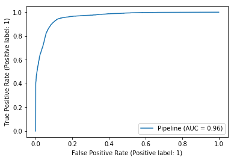

```python
# Criando o pipe.
pipe_random = Pipeline([('MinMaxScaler',MinMaxScaler(feature_range = (0, 1))),
                          ('RandomForestClassifier', RandomForestClassifier(n_estimators=num_trees,  max_leaf_nodes=2000))])

# Definindo o número de trees.
num_trees = 5000

# Testando o modelo.
modeloRandomF = predict_avaliation(x_teste_smoted, y_teste_smoted, pipe_random)
```

Utilizaremos mais dois algoritmos para tentarmos melhorar o resultado.

### 5.4 XGBClassifier (XGBoost)

Da mesma forma que fizemos com o RandomForest faremos com o **XGBClassifier**.

```python
# Importando o módulo.
from xgboost import XGBClassifier

def treina_xgb(treino_x, treino_y):

    # Pipeline com transformador e padronizador.
    pipe_escalado_padronizado = Pipeline([('MinMaxScaler',MinMaxScaler(feature_range = (0, 1))),('StandardScaler', StandardScaler()),
                          ('XGBClassifier', XGBClassifier(verbosity = 0))]).fit(treino_x, treino_y)

    pipe_padronizado = Pipeline([('StandardScaler', StandardScaler()),
                                 ('XGBClassifier', XGBClassifier(verbosity = 0))]).fit(treino_x, treino_y)

    pipe_escalado = Pipeline([('MinMaxScaler',MinMaxScaler(feature_range = (0, 1))),
                          ('XGBClassifier', XGBClassifier(verbosity = 0))]).fit(treino_x, treino_y)

    pipe_algoritmo = Pipeline([('XGBClassifier', XGBClassifier(verbosity = 0))]).fit(treino_x, treino_y)

    # Verificando os scores dos modelos.
    print('Score Escalado e Padronizado: ', round(pipe_escalado_padronizado.score(x_teste_smoted, y_teste_smoted), ndigits=3)*100)
    print('Score Padronizado: ', round(pipe_padronizado.score(x_teste_smoted, y_teste_smoted), ndigits=3)*100)
    print('Score Escalado: ', round(pipe_escalado.score(x_teste_smoted, y_teste_smoted), ndigits=3)*100)
    print('Score Apenas Modelos: ', round(pipe_algoritmo.score(x_teste_smoted, y_teste_smoted), ndigits=3)*100)

# Aplicando a função.
treina_xgb(x_train_smoted, y_train_smoted)
```

```
Score Escalado e Padronizado:  91.7
Score Padronizado:  91.7
Score Escalado:  91.7
Score Apenas Modelos:  91.7
```

Podemos ver que o XGBoost obteve o mesmo resultado com todas as formas de dados. Portanto não faremos nenhuma transformação nos dados.

```
Accuracy:  91.7

Confusion Matrix:
 [[18962  1544]
 [ 1854 18652]]

AUC (Area Under Curve):  91.7

ROC CURVE:
```

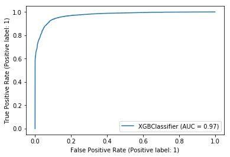

```
XGBClassifier(base_score=0.5, booster='gbtree', colsample_bylevel=1,
              colsample_bynode=1, colsample_bytree=1, gamma=0, gpu_id=-1,
              importance_type='gain', interaction_constraints='',
              learning_rate=0.300000012, max_delta_step=0, max_depth=6,
              min_child_weight=1, missing=nan, monotone_constraints='()',
              n_estimators=100, n_jobs=8, num_parallel_tree=1, random_state=0,
              reg_alpha=0, reg_lambda=1, scale_pos_weight=1, subsample=1,
              tree_method='exact', validate_parameters=1, verbosity=0)
```

```python
# Criando uma instância do algoritmo.
XClassifier = XGBClassifier(n_estimators=100, verbosity=0, booster='gbtree')

XClassifier.fit(x_train_smoted,
               y_train_smoted,
                early_stopping_rounds = 100,
                eval_metric = "auc",
                eval_set= [(x_teste_smoted, y_teste_smoted)])

# Testando o modelo.
predict_avaliation(x_teste_smoted, y_teste_smoted, XClassifier)
```

### 5.5 HistGradientBoostingClassifier

Conforme fizemos anteriormente, vamos avaliar qual a melhor forma de tratamento dos dados ao modelo.

```python
# Importando os módulos necessários.
from sklearn.experimental import enable_hist_gradient_boosting
from sklearn.ensemble import HistGradientBoostingClassifier

def treina_histGrad(treino_x, treino_y):

    # Pipeline com transformador e padronizador.
    pipe_escalado_padronizado = Pipeline([('MinMaxScaler',MinMaxScaler(feature_range = (0, 1))),('StandardScaler', StandardScaler()),
                          ('HistGradientBoostingClassifier', HistGradientBoostingClassifier())]).fit(treino_x, treino_y)

    pipe_padronizado = Pipeline([('StandardScaler', StandardScaler()),
                                 ('HistGradientBoostingClassifier', HistGradientBoostingClassifier())]).fit(treino_x, treino_y)

    pipe_escalado = Pipeline([('MinMaxScaler',MinMaxScaler(feature_range = (0, 1))),
                          ('HistGradientBoostingClassifier', HistGradientBoostingClassifier())]).fit(treino_x, treino_y)

    pipe_algoritmo = Pipeline([('HistGradientBoostingClassifier', HistGradientBoostingClassifier())]).fit(treino_x, treino_y)

    # Verificando os scores dos modelos.
    print('Score Escalado e Padronizado: ', round(pipe_escalado_padronizado.score(x_teste_smoted, y_teste_smoted), ndigits=3)*100)
    print('Score Padronizado: ', round(pipe_padronizado.score(x_teste_smoted, y_teste_smoted), ndigits=3)*100)
    print('Score Escalado: ', round(pipe_escalado.score(x_teste_smoted, y_teste_smoted), ndigits=3)*100)
    print('Score Apenas Modelos: ', round(pipe_algoritmo.score(x_teste_smoted, y_teste_smoted), ndigits=3)*100)

# Aplicando a função.
treina_histGrad(x_train_smoted, y_train_smoted)
```

```
Score Escalado e Padronizado:  91.8
Score Padronizado:  91.7
Score Escalado:  91.7
Score Apenas Modelos:  91.60000000000001
```

Podemos ver que quando os dados estão escalados e padronizados o algoritmo possui uma leve melhora. Portanto, utilizaremos os dados assim.

```
Accuracy:  91.8

Confusion Matrix:
 [[18840  1666]
 [ 1707 18799]]

AUC (Area Under Curve):  91.8

ROC CURVE:
```

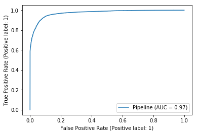

```python
# Criando o pipe.
pipe_histGrad = Pipeline([('MinMaxScaler',MinMaxScaler(feature_range = (0, 1))),('StandardScaler', StandardScaler()),
                          ('HistGradientBoostingClassifier', HistGradientBoostingClassifier(min_samples_leaf=150, max_iter=150))])

# Treiando o modelo
histGrad =  predict_avaliation(x_teste_smoted, y_teste_smoted, pipe_histGrad)
```

Com os algoritmos criados vamos salvá-los em disco.

```python
# Importando a biblioteca para gravarmos os modelos.
import pickle

# Criando uma lista com os nome e os modelos.
modelos = [('HistGradientBoostingClassifier.sav', histGrad), ('XGBClassifier.sav', XClassifier),
           ('RandomForestClassifier.sav', modeloRandomF), ('DecisionTreeClassifier.sav', decicionTree),
          ('DecisionTreeClassifierV2.sav', decicionTree_V2)]

# Criando um looping para salvar os modelos.
for arquivo, modelo in modelos:
    pickle.dump(modelo, open(arquivo, 'wb'))

print("Modelos salvos!")
```

```
Modelos salvos!
```

Com os algoritmos salvos vamos realizar as predições nos dados fornecidos pelo Kaggle.

```python
# Carregando os dados para predição.
new_data = pd.read_csv('test.csv')

# Verificando a existência de valores NA ou nulos.
print('Valores NA: ', new_data.isna().sum().sum())
print('Valores NULL: ', new_data.isnull().sum().sum())

# Ralizando o filtro das colunas
new_data = new_data[filtered_treino.columns]
```

```
Valores NA:  0
Valores NULL:  0
```

```python
for arquivo, modelo in modelos:
    # Realizando as previsões
    kaggle_previsoes = modelo.predict_proba(new_data)[:,1]

    # Lendo o arquivo para submissão dos dados.
    kaggle_submite = pd.DataFrame({'ID': pd.read_csv('sample_submission.csv').iloc[:,0],
                               'TARGET': kaggle_previsoes})

    # Salvando as predições em formato csv.
    kaggle_submite.to_csv(str(arquivo)[0:-4]+'.csv', index=False)
```

Com os arquivos de submissão salvos faremos o envio ao Kaggle para verificarmos as pontuações de cada modelo.

- **DecisionTreeClassifier:** 0.61438
- **DecisionTreeClassifierV2:** 0.62539
- **RandomForestClassifier:** 0.80005
- **XGBClassifier:** 0.78841
- **HistGradientBoostingClassifier:** 0.79608

O melhor modelo foi o **RandomForestClassifier** com um **Score de 80%**.

Com isso alcançamos o objetivo inicial de uma **acurácia de 70%**.